# fragilityindex

Fragility index for dichotomous and multivariate results

Kipp Johnson and Eli Rapoport

2017-07-31

*fragilityindex* is a package that implements and extends the fragility index calculation as described in Walsh et al. (2014).

# Introduction

## Theory

In randomized controlled trials, our belief in whether a treatment may have a real effect is often influenced by whether hypothesis testing demonstrates statistical significance. Typically, hypothesis testing rejects the null hypothesis when the P-value is below a predetermined threshold. Rejecting the null hypothesis suggests that the differences between treatment groups are unlikely to have occured due to chance.

Per Walsh et al. (2014), the use of threshold P-values may be an overly simple concept to determine the existence of a treatment effect. They are limited as a tool since readers may interpret P-values of similar magnitude similarly, regardless of sample size or number of trials. Also, P-values near the threshold value are interpreted very differently, depending on whether they are above or below it.

Walsh et al. (2014) suggest the use of an additional metric that demonstrates how easily a significant result can lose statistical signifance as a result of additional events being added to the results. This metric, the fragility index, indicates fragile results with smaller numbers, and non-fragile results with large ones.

The fragility index estimates how fragile statistical results are to small perturbations in event outcomes. This package implements an extension to the fragility index calculation for dichotomous results that can be used to estimate the fragility of statistical significance of predictors in linear, logistic, and Cox P-H (survival analysis) regression models.

## Multivariate Fragility

### Concept

Potential covariates for multivariate regressions are often assessed for significant effects using hypothesis testing. This allows the concept of the fragility index to be extended to models. However, since the majority of data does not have dichotomous outcomes, we cannot simply flip outcomes like the fragility index proposed by Walsh et al. (2014) calls for. Even for models with dichotomous outcomes, such as those used in survival analysis, specific event outcomes are associated with specific survival times and cannot be simply permuted.

Since a fragile test result is one which could have resulted in a p-value greater than alpha with slight dataset perturbation, the fragility index of a covariate in a multivariate regression can be defined as the minimum number of points one must remove before a model with that covariate is not significantly different from a model without that covariate.

### Comparing Function Outputs

The functions `logisticfragility`, `linearfragility`, and `survivalfragility` return approximations for fragility indices of multivariate regressions. These estimates should not be compared between different model types since each of the functions has a slightly different method of making these approximations. Generally, they search for points which favor the full model over the one missing a covariate and remove these points until the models are not distinguishable at the given confidence level.

Covariates of similar fragility will yield the lowest fragility indices for logistic models and the highest for Cox P-H regressions in survival analysis. The algorithms for prioritizing points for removal from the dataset are closest to optimal for logistic regressions, while Cox P-H regressions have two response variables, weakening point selection and inflating fragility index values. We recommend comparing fragility index values within models, rather than between models. Oftentimes, differences in sample sizes also make comparisons of fragility between models is relatively meaningless. The most effective ways to use fragility index approximations are described in the sections for each function. The algorithms used to find them are also briefly described. The algorithm for `logisticfragility` is described in detail in the appendix. It can be generalized to understand the other multivariate functions.

## *fragilityindex* Functions

Four of the functions in *fragilityindex* compute fragility indices for specific hypothesis tests:

- `fragility.index`
  - Implements fragility index per Walsh et al. (2014).
  - Estimates fragility of hypothesis testing using Fisher’s exact test and Pearson’s chi-squared test of homogeneity on dichotomous results.
- `logisticfragility`
  - Estimates fragility of significance of effects of selected predictor variables for logistic regression using Likelihood-ratio test.
- `linearfragility`
  - Estimates fragility of significance of effects of selected predictor variables for linear regression using Likelihood-ratio test.
- `survivalfragility`
  - Estimates fragility of significance of effects of selected predictor variables for Cox proportional hazards regression model using Pearson’s chi-squared test of goodness of fit.

`revfragility.index` estimates the fragility of nonsignificant results from a test of homogeneity on dichotomous results. It can be seen as the reverse of `fragility.index` since it reports the number of flipped outcomes to make a nonsignificant outcome significant.

# Functions

```r
library(fragilityindex)
```

## *fragility.index()*

*fragility.index(intervention_event, control_event, intervention_n, control_n, conf.level=0.95, verbose=FALSE, print.mat=FALSE)*

We can use `fragility.index` to estimate the fragility of hypothesis testing using Pearson’s chi-squared test or Fisher’s exact test on dichotomous data from two groups.

The following table presents data for which the fragility index can provide insight. The data is made up of two groups, one which received the experimental treatment, while the other recieved the control treatment. The control treatment group has 5 recorded events with a sample size of 40 individuals and the experimental treatment group has 15 events with a sample size of 41 individuals.

|  | Control | Experimental |
| --- | --- | --- |
| **Events** | 5 | 15 |
| **Sample Size** | 40 | 41 |

Formatting the data for Chi-squared test:

```r
control_events <- 5; control_sample <- 40
exp_events <- 15; exp_sample <- 41

mat <- matrix(c(control_events, exp_events, control_sample - control_events, exp_sample- exp_events), byrow = TRUE, 2, 2)
```

First we conduct a Pearson’s Chi-squared test at an alpha of 0.05.

```r
chisq.test(mat)
```

```
##
##  Pearson's Chi-squared test with Yates' continuity correction
##
## data:  mat
## X-squared = 5.0876, df = 1, p-value = 0.0241
```

This gives us a p-value of 0.0241, which is less than our alpha threshold of 0.05, indicating that the difference between the control and experimental groups is significant. To check the fragility of this result, we can use the `fragility.index` function.

```r
fragility <- fragility.index(exp_events, control_events, exp_sample, control_sample, conf.level = 1 - alpha)
```

A fragility index of 2 is concerning for a sample size of 40. It means that if 2 more members of the control group experienced an event, we would have found the groups to not be statistically significantly different. Especially in cases where subjects are lost due to failure to follow-up or other random events which prevent them from being recorded as a success or failure, this is very concerning. To see the changes done to the data, we can set `print.mat = TRUE`.

```r
fragility.index(exp_events, control_events, exp_sample, control_sample, print.mat = TRUE)
```

```
##      [,1] [,2]
## [1,]   15   26
## [2,]    6   34
##      [,1] [,2]
## [1,]   15   26
## [2,]    7   33
```

```
## $index
## [1] 2
```

The fragility index is stored under `$index` in a list. We can see the number of events increase by 1 each iteration while the number of non-events decreases by 1. The final matrix printed has nonsignificant differences between the two groups.

If we want to record the p-value associated with each iteration of flipping a non-event to event, we can set `verbose = TRUE`. This will cause the function to output p-values for each iteration, up to and including the iteration which makes the groups not significantly different.

```r
fragility_object = fragility.index(exp_events, control_events, exp_sample, control_sample, verbose = TRUE)
fragility_object
```

```
##   index p.value
## 1     0   0.019
## 2     1   0.041
## 3     2   0.080
```

The p-value next to the 0 entry for `fragility.index` is the p-value for Fisher’s exact test on the original data. If the two groups are not statistically significantly different at the given confidence level with this test, `fragility.index()` will return 0 as the fragility index.

## *revfragility.index*

*revfragility.index(intervention_event, control_event, intervention_n, control_n, conf.level=0.95, verbose=FALSE, print.mat=FALSE)*

When hypothesis testing of dichotomous data using Pearson’s chi-squared test or Fisher’s exact test fails to reject a null hypothesis, we can use `revfragility.index` to estimate the fragility of the test’s conclusion. We use the term “reverse fragility” to refer to the fragility of a nonsignificant result from hypothesis testing.

The following table presents dichotomous data from two different groups. The control treatment group has 5 recorded events with a sample size of 40 individuals and the experimental treatment group has 15 events with a sample size of 41 individuals.

|  | Control | Experimental |
| --- | --- | --- |
| **Events** | 5 | 15 |
| **Sample Size** | 40 | 41 |

Formatting the data for Chi-squared test:

```r
control_events <- 5; control_sample <- 40
exp_events <- 15; exp_sample <- 41

mat <- matrix(c(control_events, exp_events, control_sample - control_events, exp_sample- exp_events), byrow = TRUE, 2, 2)
```

First we conduct a Pearson’s Chi-squared test at an alpha of 0.01.

```r
chisq.test(mat)
```

```
##
##  Pearson's Chi-squared test with Yates' continuity correction
##
## data:  mat
## X-squared = 5.0876, df = 1, p-value = 0.0241
```

This gives us a p-value of 0.0241, which is greater than our alpha threshold of 0.01, indicating that the difference between the control and experimental groups is not significant. To check the reverse fragility of this result, we can use the `revfragility.index` function.

```r
library(fragilityindex)
revfragility <- revfragility.index(exp_events, control_events, exp_sample, control_sample, conf.level = 1 - alpha)
```

```r
revfragility
```

```
## $index
## [1] 1
```

Similarly to the `fragility.index` function, we can set `print.mat = TRUE` to see the changes done to the table of data to simulate a significant result.

The reverse fragility index is stored under `$index` in a list.

If we want to record the p-value associated with each iteration of flipping an event to a non-event, we can set `verbose = TRUE`. This will cause the function to output p-values for each iteration, up to and including the iteration which makes the groups significantly different.

```r
fragility_object = revfragility.index(exp_events, control_events, exp_sample, control_sample, verbose = TRUE, conf.level = 1 - alpha)
fragility_object
```

```
##   index p.value
## 1     0   0.019
## 2     1   0.004
```

The p-value next to the 0 entry for `fragility.index` is the p-value for Fisher’s exact test on the original data. If the two groups are statistically significantly different at the given confidence level with this test, `revfragility.index()` will return 0 as the reverse fragility index.

```r
revfragility.index(exp_events, control_events, exp_sample, control_sample, verbose = TRUE, conf.level = 0.95)
```

```
##   index    p.value
## 1     0 0.01925231
```

# Appendix

## Logistic Model Fragility Index Calculation

Simulating bivariate logistic data:

```r
n <- 100; b0 <- -5; b1 <- .055; b2 <- .2
x <- runif(n, min = 1, max = 100)
x2 <- runif(n, min = 1, max = 20)
pi <- (exp(b0 + b1 * x + b2 * x2)) / (1 + exp(b0 + b1 * x + b2 * x2))
y <- rbinom(n, 1, pi)
mydata <- data.frame(x, x2, y)
names(mydata) <- c("Var", "Covar", "Status")
head(mydata)
        Var     Covar Status
1 12.101419 15.563084      0
2 88.570104 12.579044      1
3 80.729309 15.994316      1
4  4.324241  5.289035      0
5 55.362409  4.695393      0
6 94.017272 19.019734      1
```

`Status` is the response variable and `Var` and `Covar` are covariates for our logistic model. Note that `Status` has dichotomous outcomes.

```r
model <-  glm(Status ~ Var + Covar, mydata, family = "binomial")
summary(model)

Call:
glm(formula = Status ~ Var + Covar, family = "binomial", data = mydata)

Deviance Residuals:
    Min       1Q   Median       3Q      Max
-2.1567  -0.6678  -0.2879   0.5316   2.3431

Coefficients:
            Estimate Std. Error z value Pr(>|z|)
(Intercept) -5.11859    0.96430  -5.308 1.11e-07 ***
Var          0.05203    0.01147   4.535 5.77e-06 ***
Covar        0.20060    0.05110   3.926 8.65e-05 ***
---
Signif. codes:  0 '***' 0.001 '**' 0.01 '*' 0.05 '.' 0.1 ' ' 1

(Dispersion parameter for binomial family taken to be 1)

    Null deviance: 131.791  on 99  degrees of freedom
Residual deviance:  84.229  on 97  degrees of freedom
AIC: 90.229

Number of Fisher Scoring iterations: 5
```

Both covariates are found to be significant at a 95% confidence level. The goal of the `logisticfragility` function is to determine the number of points on must remove to make the covariates nonsignificant at our chosen confidence level. The logistic model generated by `glm` for our data shows a significant relationship between `Var` and `Response`.

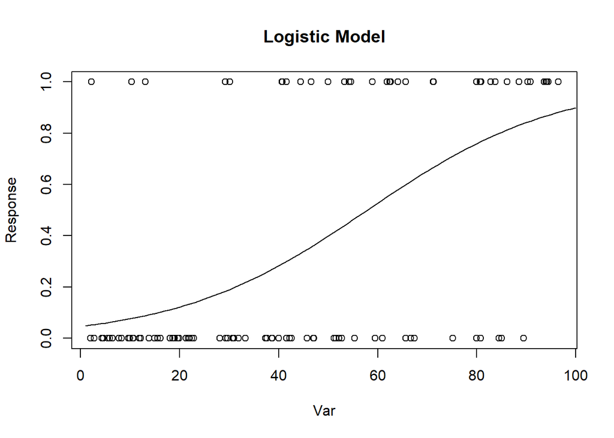

A model with a nonsignificant p-value for a covariate is one not found to be significantly different from a model without that covariate. We shall call that model `nullmodel`.

```r
nullmodel <- glm(Status ~ Covar, mydata, family = "binomial")
summary(nullmodel)

Call:
glm(formula = Status ~ Covar, family = "binomial", data = mydata)

Deviance Residuals:
    Min       1Q   Median       3Q      Max
-1.5936  -0.8233  -0.5789   1.0161   2.0486

Coefficients:
            Estimate Std. Error z value Pr(>|z|)
(Intercept) -2.21000    0.51670  -4.277 1.89e-05 ***
Covar        0.16111    0.04226   3.812 0.000138 ***
---
Signif. codes:  0 '***' 0.001 '**' 0.01 '*' 0.05 '.' 0.1 ' ' 1

(Dispersion parameter for binomial family taken to be 1)

    Null deviance: 131.79  on 99  degrees of freedom
Residual deviance: 114.66  on 98  degrees of freedom
AIC: 118.66

Number of Fisher Scoring iterations: 3
```

Using the Likelihood Ratio Test, we can see that the two models are significantly different.

```r
anova(model,nullmodel,test = "LRT")
Analysis of Deviance Table

Model 1: Status ~ Var + Covar
Model 2: Status ~ Covar
  Resid. Df Resid. Dev Df Deviance  Pr(>Chi)
1        97     84.229
2        98    114.659 -1   -30.43 3.461e-08 ***
---
Signif. codes:  0 '***' 0.001 '**' 0.01 '*' 0.05 '.' 0.1 ' ' 1
```

Rather than removing points randomly, it is possible to isolate points which favor the complete model with the covariate over the model without it. There are four cases we can sort all of the points into:

1. Points with `Response = 1` at values of `Var` where `model` predicts a higher probability than `nullmodel`.
2. Points with `Response = 1` at values of `Var` where `model` predicts a lower probability than `nullmodel`.
3. Points with `Response = 0` at values of `Var` where `model` predicts a higher probability than `nullmodel`.
4. Points with `Response = 0` at values of `Var` where `model` predicts a lower probability than `nullmodel`.

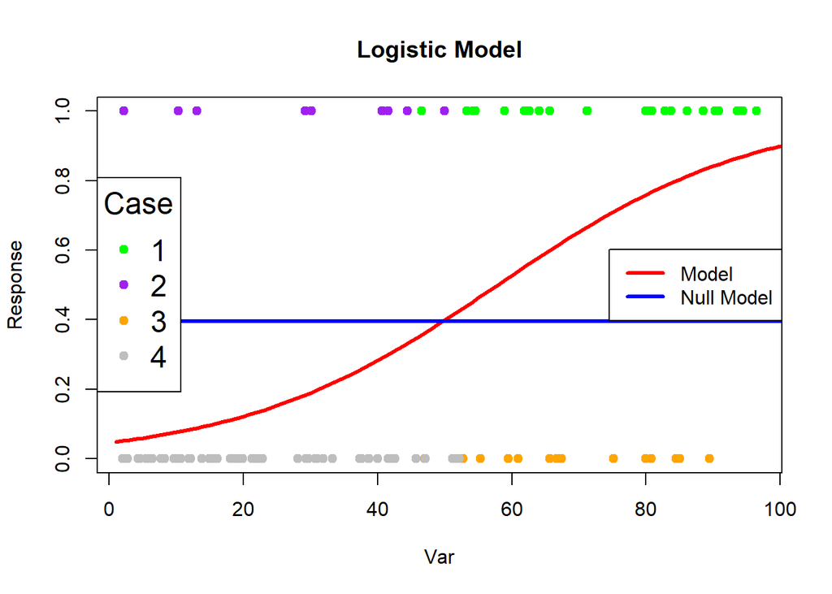

The two lines shown are simplified versions of `model` and `nullmodel`, predicting `Response` using the mean of `Covar` in addition to `Var`. The points are categorized into cases using the unsimplified model so points with values of `Var` near the boundary of `model` = `nullmodel’ cannot be predicted simply by observing the plot.

The removal of points in Cases 1 and 4 results in the convergence of `model` and `nullmodel`. The full model has higher predictive power for these points than the model without `Var`. These points can be found by taking the difference in residuals from the two models. Residuals in Cases 1 and 2 are positive while those in Cases 3 and 4 are negative. The residuals of `model` minus the residuals of `nullmodel` are positive in Cases 2 and 4 while those in Cases 1 and 3 are negative. By selecting points where the difference in residuals is negative with `Response` = 1 and where the difference in residuals is positive with `Response` = 0, we can isolate points which lead to a nonsignificant difference in `model` and `nullmodel` by the Likelihood Ratio Test. When selected in order by magnitude of difference in residuals, these two models converge quickly.

Using this method, the `logisticfragility` function returns that removing 17 points can lead to a model in which `Var` is not statistically significant.

It must be remembered that the removal of points will inevitable lead to a model being found to have nonsignificant covariates, regardless of the points that are selected. This algorithm attempts to find the fastest path to this result.

```r
logisticfragility(Status ~ Var + Covar, mydata)
$Var
$Var$fragility.index
[1] 17


$Covar
$Covar$fragility.index
[1] 11
```

The points removed with this method, and the resulting p-value after removing each point are:

```r
verboseresults <- logisticfragility(Status ~ Var + Covar, covariate = "Var", mydata, verbose = TRUE)
verboseresults
$Var
$Var$fragility.index
[1] 17

$Var$point.diagnostics
         Var     Covar Status resulting.pval
18 82.795982  1.505662      1   1.124409e-07
70 86.168925  2.238656      1   4.227435e-07
46 71.220365  2.115942      1   9.513140e-07
57 93.947640  7.480141      1   3.395790e-06
86  2.775811 19.552376      0   1.070464e-05
19 94.431068  8.536165      1   3.536046e-05
58  7.712649 18.409971      0   9.715587e-05
79 96.469798 10.872889      1   2.456083e-04
16 62.569753  7.102042      1   4.505765e-04
90 21.993972 18.246661      0   9.271021e-04
87 83.704706 12.194020      1   1.769378e-03
1  12.101419 15.563084      0   3.406399e-03
2  88.570104 12.579044      1   6.362306e-03
95 61.901424  8.862344      1   1.081692e-02
34 90.853610 12.875146      1   2.037078e-02
91 94.126643 13.281939      1   3.795527e-02
76 19.933992 15.134136      0   5.606641e-02
```

The points selected for removal are identified in red on this scatterplot.

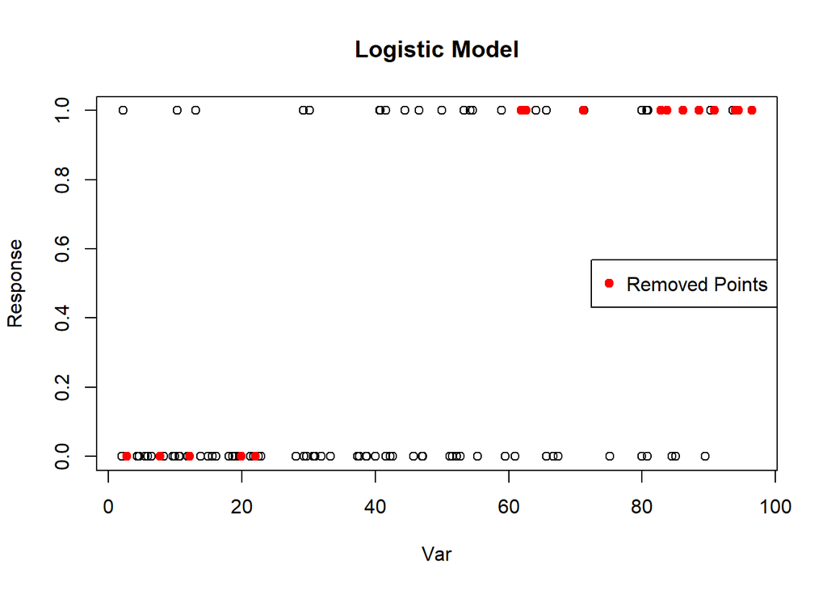

The new model fit to the perturbed data is `nonsigmodel` while the new null model is `nonsignullmodel`. `Var` is no longer statistically significant while `Covar` is, since points which demonstrate `Var`’s explanatory effect on variation within `Response` have been removed.

```r
newdata = mydata[ ! mydata$Var %in% points, ]
nonsigmodel <-  glm(Status ~ Var + Covar, newdata, family = "binomial")
nonsignullmodel <- glm(Status ~ Covar, newdata, family = "binomial")
summary(nonsigmodel)

Call:
glm(formula = Status ~ Var + Covar, family = "binomial", data = newdata)

Deviance Residuals:
    Min       1Q   Median       3Q      Max
-2.1200  -0.4742  -0.2706   0.5455   2.6747

Coefficients:
            Estimate Std. Error z value Pr(>|z|)
(Intercept) -5.21726    1.04750  -4.981 6.34e-07 ***
Var          0.02417    0.01306   1.850   0.0643 .
Covar        0.29734    0.06843   4.345 1.39e-05 ***
---
Signif. codes:  0 '***' 0.001 '**' 0.01 '*' 0.05 '.' 0.1 ' ' 1

(Dispersion parameter for binomial family taken to be 1)

    Null deviance: 101.572  on 82  degrees of freedom
Residual deviance:  61.441  on 80  degrees of freedom
AIC: 67.441

Number of Fisher Scoring iterations: 5
```

It can be seen that these models have converged.

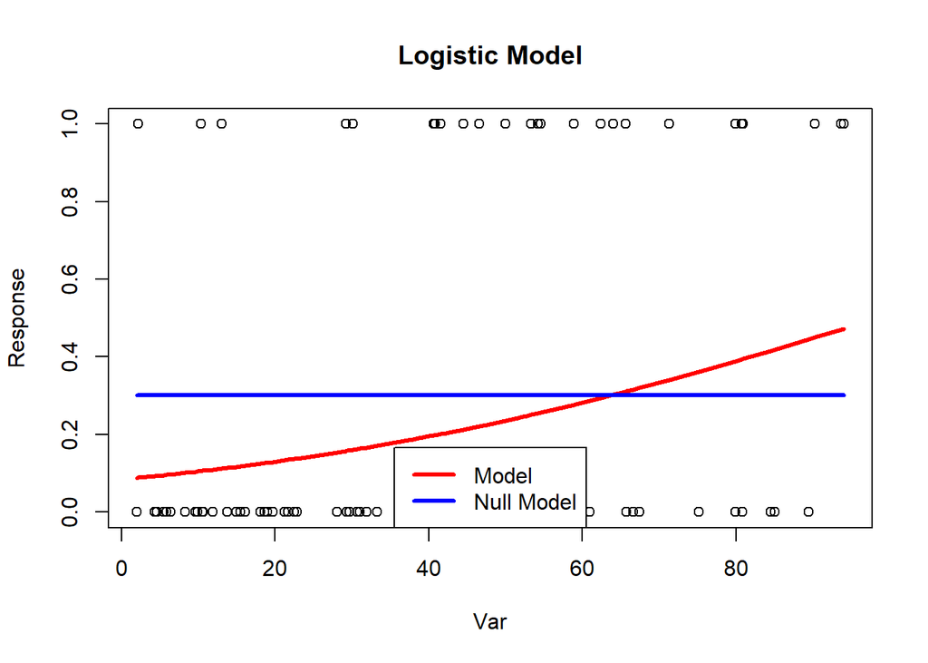

If we run an ANOVA, comparing a model with `Var` and a model without `Var`, we will find that `Var` is no longer statistically significant after the data perturbation.

```r
anova(nonsigmodel,nonsignullmodel,test = "LRT")
Analysis of Deviance Table

Model 1: Status ~ Var + Covar
Model 2: Status ~ Covar
  Resid. Df Resid. Dev Df Deviance Pr(>Chi)
1        80     61.441
2        81     65.091 -1  -3.6501  0.05607 .
---
Signif. codes:  0 '***' 0.001 '**' 0.01 '*' 0.05 '.' 0.1 ' ' 1
```